# TP modèles linéaires - Partie 1

Cathy Maugis-Rabusseau & Pierre Neuvial

2021-06-29

Les librairies R nécessaires pour ce TP :

```r
library(ellipse)
library(leaps)
library(MASS)
library(corrplot)
library(glmnet)
library(ggplot2)
library(gridExtra)
library(ggfortify)
library(plotly)
library(tidyverse)
library(FactoMineR)
```

# 1 Présentation des données

La pollution de l’air constitue actuellement une des préoccupations majeures de santé publique. De nombreuses études épidémiologiques ont permis de mettre en évidence l’influence sur la santé de certains composés chimiques comme le dioxyde souffre (SO2), le dioxyde d’azote (NO2), l’ozone (O3) ou des particules en suspension. Des associations de surveillance de la qualité de l’air (Air Breizh en Bretagne depuis 1994) existent sur tout le territoire métropolitain et mesurent la concentration des polluants. Elles enregistrent également les conditions météorologiques comme la température, la nébulosité, le vent, les chutes de pluie en relation avec les services de Météo France… L’une des missions de ces associations est de construire des modèles de prévision de la concentration en ozone du lendemain à partir des données disponibles du jour : observations et prévisions de Météo France. Plus précisément, il s’agit d’anticiper l’occurrence ou non d’un dépassement légal du pic d’ozone (180 $\mu$gr/m3) le lendemain afin d’aider les services préfectoraux à prendre les décisions nécessaires de prévention : confinement des personnes à risque, limitation du trafic routier. Plus modestement, l’objectif de cette étude est de mettre en évidence l’influence de certains paramètres sur la concentration d’ozone (en $\mu$gr/m3) et différentes variables observées ou leur prévision. Les 112 données étudiées ont été recueillies à Rennes durant l’été 2001.

Les 13 variables observées sont :

- maxO3 : Maximum de concentration d’ozone observé sur la journée en $\mu$gr/m3
- T9, T12, T15 : Température observée à 9, 12 et 15h
- Ne9, Ne12, Ne15 : Nébulosité observée à 9, 12 et 15h
- Vx9, Vx12, Vx15 : Composante E-O du vent à 9, 12 et 15h
- maxO3v : Teneur maximum en ozone observée la veille
- vent : orientation du vent à 12h
- pluie : occurrence ou non de précipitations

Les données sont disponibles dans le fichier “Ozone.txt” sur la page https://github.com/cmaugis/Stat-Avancees---PFB-Toulouse (dossier Data/).

Pour les lire, vous pouvez utiliser la commande suivante :

```r
url <- url("https://raw.githubusercontent.com/cmaugis/Stat-Avancees---PFB-Toulouse/main/Data/Ozone.txt")
ozone = read.table(url)
```

```r
ozone$vent <- as.factor(ozone$vent)
ozone$pluie <- as.factor(ozone$pluie)
summary(ozone)
```

```
     maxO3              T9             T12             T15
 Min.   : 42.00   Min.   :11.30   Min.   :14.00   Min.   :14.90
 1st Qu.: 70.75   1st Qu.:16.20   1st Qu.:18.60   1st Qu.:19.27
 Median : 81.50   Median :17.80   Median :20.55   Median :22.05
 Mean   : 90.30   Mean   :18.36   Mean   :21.53   Mean   :22.63
 3rd Qu.:106.00   3rd Qu.:19.93   3rd Qu.:23.55   3rd Qu.:25.40
      Ne9             Ne12            Ne15           Vx9
 Min.   :0.000   Min.   :0.000   Min.   :0.00   Min.   :-7.8785
 1st Qu.:3.000   1st Qu.:4.000   1st Qu.:3.00   1st Qu.:-3.2765
 Median :6.000   Median :5.000   Median :5.00   Median :-0.8660
 Mean   :4.929   Mean   :5.018   Mean   :4.83   Mean   :-1.2143
 3rd Qu.:7.000   3rd Qu.:7.000   3rd Qu.:7.00   3rd Qu.: 0.6946
      Vx12             Vx15            maxO3v          vent      pluie
 Min.   :-7.878   Min.   :-9.000   Min.   : 42.00   Est  :10   Pluie:43
 1st Qu.:-3.565   1st Qu.:-3.939   1st Qu.: 71.00   Nord :31   Sec  :69
 Median :-1.879   Median :-1.550   Median : 82.50   Ouest:50
 Mean   :-1.611   Mean   :-1.691   Mean   : 90.57   Sud  :21
 3rd Qu.: 0.000   3rd Qu.: 0.000   3rd Qu.:106.00
 [ getOption("max.print") est atteint -- ligne 1 omise ]
```

# 2 Quelques statistiques descriptives

Afin de se familiariser avec les données, nous allons faire quelques statistiques descriptives.

Distribution des variables quantitatives :

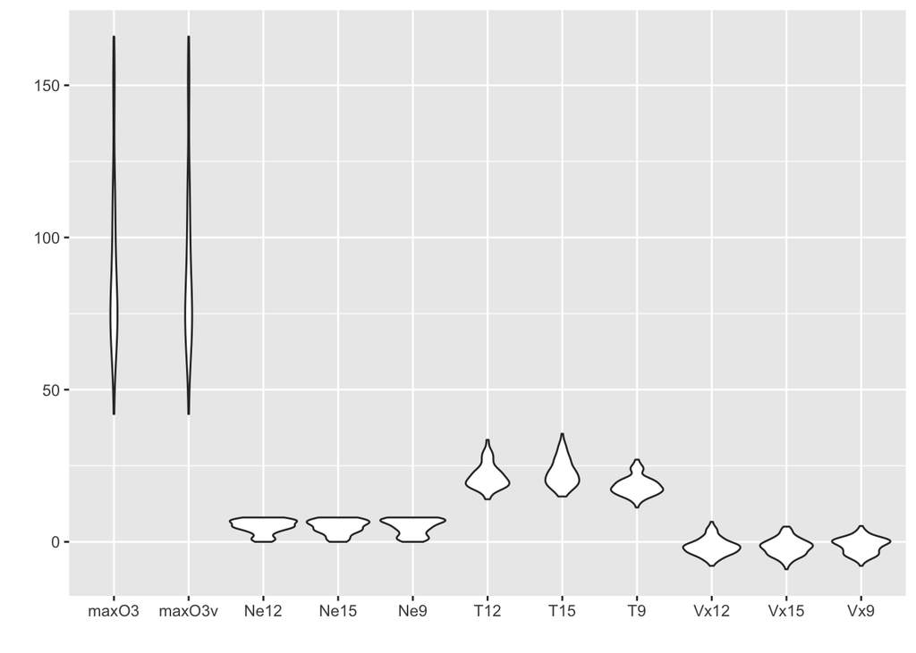

```r
oz_quanti <- ozone[, 1:11]
A <- data.frame(y = as.vector(as.matrix(t(oz_quanti))), x = rep(colnames(oz_quanti),
    nrow(oz_quanti)))
ggplot(A, aes(x = x, y = y)) + geom_violin() + xlab("") + ylab("")
```

Répartition des variables qualitatives *vent* et *pluie* :

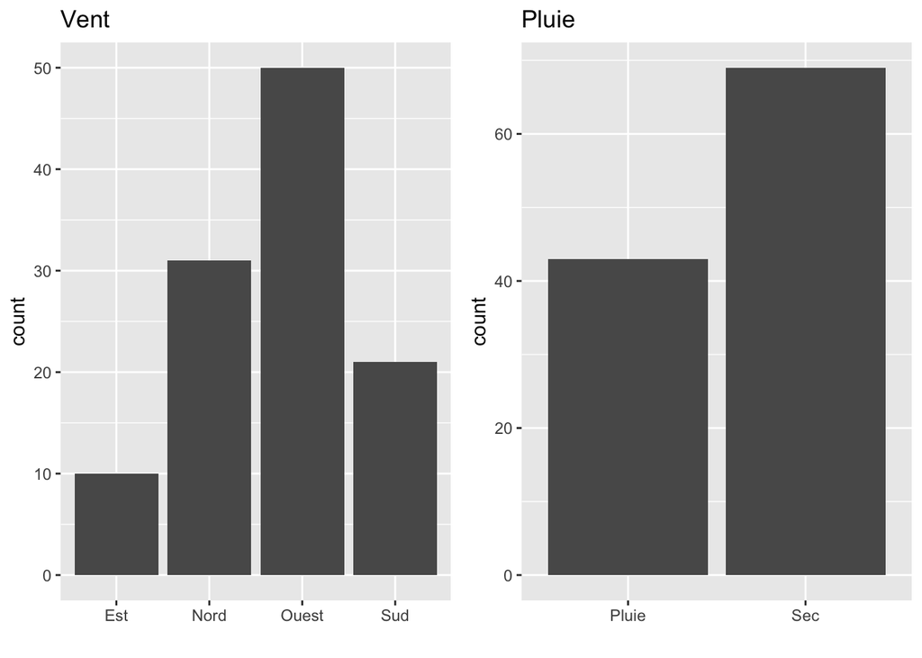

```r
g1 <- ggplot(ozone, aes(x = vent)) + geom_bar() + xlab("") + ggtitle("Vent")
g2 <- ggplot(ozone, aes(x = pluie)) + geom_bar() + xlab("") + ggtitle("Pluie")
grid.arrange(g1, g2, ncol = 2)
```

Matrice des corrélations entre variables quantitatives :

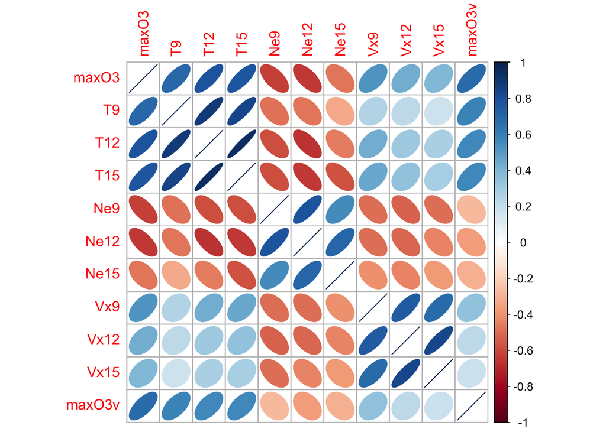

```r
corrplot(cor(oz_quanti), method = "ellipse")
```

Analyse en composantes principales :

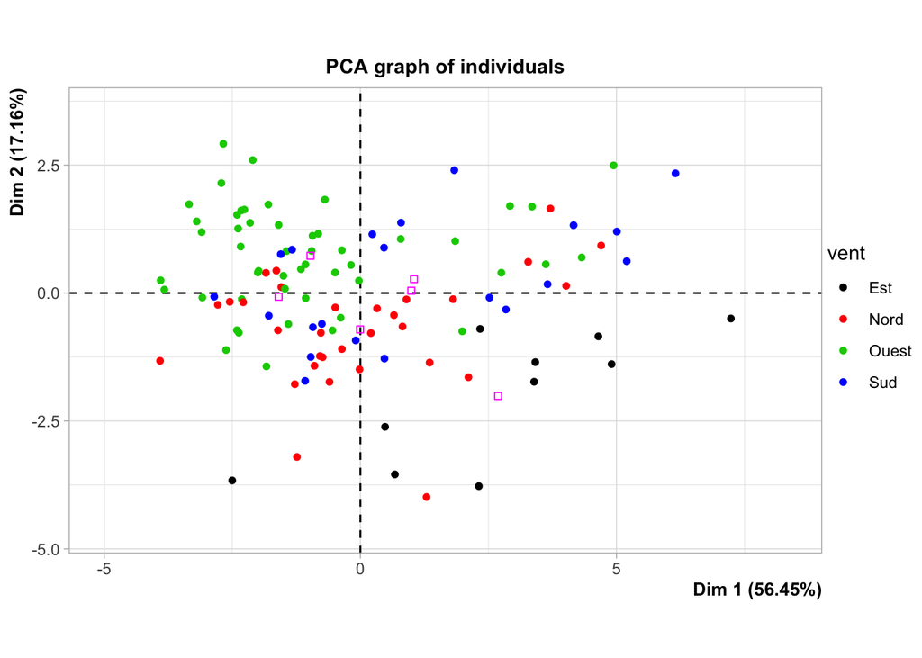

```r
respca <- PCA(ozone, scale.unit = TRUE, quali.sup = c(12, 13), graph = FALSE)
plot(respca, choix = "ind", habillage = 12, label = "none")
```

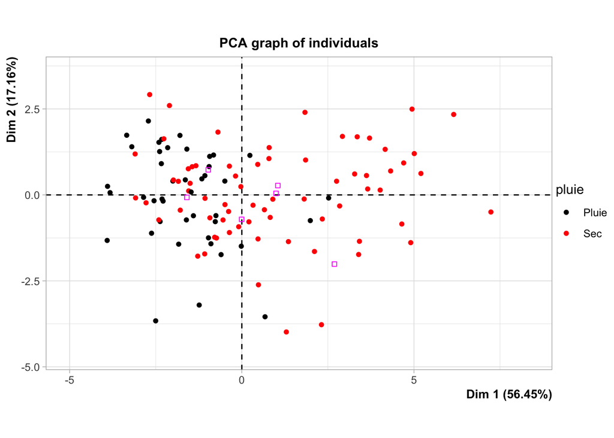

```r
plot(respca, choix = "ind", habillage = 13, label = "none")
```

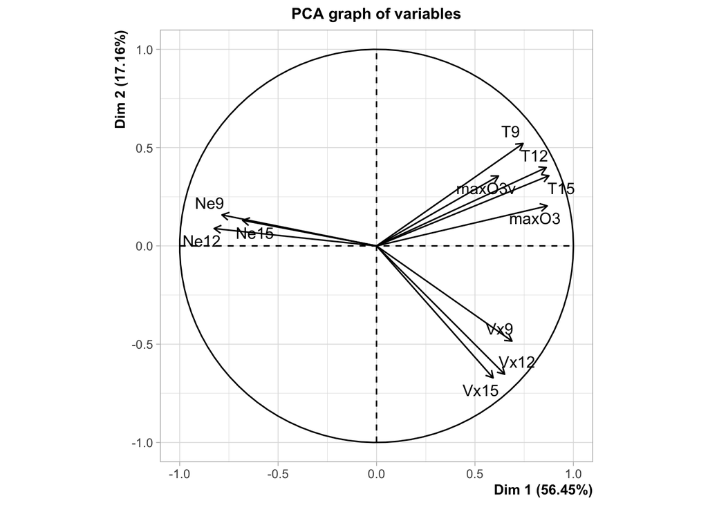

```r
plot(respca, choix = "varcor")
```

# 3 Régression linéaire

Dans cette partie, nous souhaitons analyser la relation entre le maximum journalier de la concentration d’ozone (*maxO3*) et les variables quantitatives :

- la température à différentes heures de la journée (*T9, T12, T15*),
- la nébulosité à différentes heures de la journée (*Ne9, Ne12, Ne15*),
- la projection du vent sur l’axe Est-Ouest à différentes heures de la journée (*Vx9, Vx12,Vx15*),
- la concentration maximale d’ozone de la veille (*maxO3v*)

On va donc utiliser le sous-jeu de données `oz_quanti` et mettre en place un modèle de régression linéaire multiple.

## 3.1 Question 1

Représentez le nuage de points $(x_i,y_i)$ à l’aide de la fonction `plot()` (ou `geom_point` de *ggplot2*) de maxO3 par rapport à T12, Ne9, Vx15 et maxO3v respectivement.

```r
# A COMPLETER
```

Commentez.

## 3.2 Question 2

```r
# A COMPLETER reg <-lm(....)
```

Que contiennent les sorties suivantes ?

```r
reg$coefficients
reg$residuals
```

## 3.3 Question 3

A l’aide de la fonction `autoplot()` du package *ggfortify*, etudiez les résidus du modèle afin de vérifier les hypothèses du modèle.

```r
# autoplot(...)
```

## 3.4 Question 4

A l’aide d’une procédure de sélection de variables (que l’on étudiera plus précisément dans la partie 2 du cours), un sous-modèle avec les variables explicatives T12, Ne9, Vx9 et maxO3v est proposé pour expliquer linéairement maxO3.  
A l’aide de la fonction `anova()` testez si on peut retenir ce sous-modèle par rappport au modèle complet. Commentez.

```r
reg.fin = lm(...)
anova(reg.fin, reg)
```

## 3.5 Question 5

Comparez les valeurs ajustées pour maxO3 par le modèle complet (*reg*) et le modèle simplifié (*reg.fin*).

## 3.6 Question 6

Comparez les valeurs de SSE, SSR et $R^2$ entre le modèle simplifié (*reg.fin*) et le modèle complet (*reg*)

# 4 ANOVA à un facteur

Dans cette section, nous souhaitons analyser la relation entre la concentration maximale d’ozone (maxO3) et la direction du vent (vent). On va pour cela mettre en place un modèle d’ANOVA à un facteur

$$\left\{\begin{array}{l} maxO3_{ij}= \mu + \alpha_i +\varepsilon_{ij},\ \
i=1,\ldots,I=4,\ j=1,\ldots,n_i.\\ (\varepsilon_{ij})_{i,j} \textrm{ i.i.d
}\mathcal{N}(0,\sigma^2) \end{array}\right.$$

## 4.1 Question 1

Représentez la concentration maximale d’ozone en fonction du vent. Commentez

```r
ggplot(ozone, aes(x = vent, y = maxO3)) + geom_violin()
```

## 4.2 Question 2

Utilisez la fonction `lm()` pour ajuster un modèle d’ANOVA à un facteur. Commentez.

```r
# aovent = lm (...)
```

## 4.3 Question 3

A l’aide de la fonction `anova()`, testez la significativité du facteur vent. Commentez.

```r
# anova(....)
```

## 4.4 Question 4

Comparez les différents résultats obtenus par les commandes suivantes.

```r
summary(lm(maxO3 ~ vent, data = ozone))
```

```
Call:
lm(formula = maxO3 ~ vent, data = ozone)

Residuals:
    Min      1Q  Median      3Q     Max
-60.600 -16.807  -7.365  11.478  81.300

Coefficients:
            Estimate Std. Error t value Pr(>|t|)
(Intercept)  105.600      8.639  12.223   <2e-16 ***
ventNord     -19.471      9.935  -1.960   0.0526 .
ventOuest    -20.900      9.464  -2.208   0.0293 *
ventSud       -3.076     10.496  -0.293   0.7700
---
Signif. codes:  0 '***' 0.001 '**' 0.01 '*' 0.05 '.' 0.1 ' ' 1

Residual standard error: 27.32 on 108 degrees of freedom
Multiple R-squared:  0.08602,   Adjusted R-squared:  0.06063
F-statistic: 3.388 on 3 and 108 DF,  p-value: 0.02074
```

```r
summary(lm(maxO3 ~ C(vent, base = 2), data = ozone))
```

```
Call:
lm(formula = maxO3 ~ C(vent, base = 2), data = ozone)

Residuals:
    Min      1Q  Median      3Q     Max
-60.600 -16.807  -7.365  11.478  81.300

Coefficients:
                   Estimate Std. Error t value Pr(>|t|)
(Intercept)          86.129      4.907  17.553   <2e-16 ***
C(vent, base = 2)1   19.471      9.935   1.960   0.0526 .
C(vent, base = 2)3   -1.429      6.245  -0.229   0.8194
C(vent, base = 2)4   16.395      7.721   2.123   0.0360 *
---
Signif. codes:  0 '***' 0.001 '**' 0.01 '*' 0.05 '.' 0.1 ' ' 1

Residual standard error: 27.32 on 108 degrees of freedom
Multiple R-squared:  0.08602,   Adjusted R-squared:  0.06063
F-statistic: 3.388 on 3 and 108 DF,  p-value: 0.02074
```

```r
summary(lm(maxO3 ~ C(vent, sum), data = ozone))
```

```
Call:
lm(formula = maxO3 ~ C(vent, sum), data = ozone)

Residuals:
    Min      1Q  Median      3Q     Max
-60.600 -16.807  -7.365  11.478  81.300

Coefficients:
              Estimate Std. Error t value Pr(>|t|)
(Intercept)     94.738      3.053  31.027   <2e-16 ***
C(vent, sum)1   10.862      6.829   1.590   0.1147
C(vent, sum)2   -8.609      4.622  -1.863   0.0652 .
C(vent, sum)3  -10.038      4.097  -2.450   0.0159 *
---
Signif. codes:  0 '***' 0.001 '**' 0.01 '*' 0.05 '.' 0.1 ' ' 1

Residual standard error: 27.32 on 108 degrees of freedom
Multiple R-squared:  0.08602,   Adjusted R-squared:  0.06063
F-statistic: 3.388 on 3 and 108 DF,  p-value: 0.02074
```

## 4.5 Question 5

Au vu des différentes conclusions, quelle modification de la variable vent peut-on considérer pour expliquer la concentration en ozone ? Vérifiez numériquement.

# 5 ANOVA à deux facteurs

Dans cette section, nous souhaitons analyser la relation entre la concentration maximale d’ozone (maxO3) avec la direction du vent (vent) et la précipitation (pluie). On va donc mettre en place un modèle d’analyse de la variance à deux facteurs.

```r
table(ozone$vent, ozone$pluie)
```

```
        Pluie Sec
  Est       2   8
  Nord     10  21
  Ouest    26  24
  Sud       5  16
```

## 5.1 Question 1

Représentez la concentration en ozone pour chaque modalité croisée du vent et de la pluie à l’aide de la commande suivante et commentez.

```r
ggplot(ozone, aes(x = vent, y = maxO3, fill = pluie)) + geom_boxplot()
```

## 5.2 Question 2

Mettez en place un modèle d’analyse de la variance avec interaction. Commentez les résultats.

```r
# mod.int = lm(...)
```

## 5.3 Question 3

A l’aide de la fonction `anova()`, testez si l’on peut simplifier ce modèle d’ANOVA à deux facteurs avec interaction.

# 6 Analyse de la covariance

Dans cette partie, on s’intéresse à la relation du taux maximal d’ozone (*maxO3*) par rapport à celui de la veille (*maxO3v*) et en fonction des précipitations (*pluie*). Pour cela, on va mettre en place un modèle d’analyse de la covariance.

## 6.1 Question 1

A l’aide des commandes suivantes, représentez le nuage de points entre la variable à expliquer *maxO3* et la variable quantitative explicative *maxO3v*, en fonction des modalités de la variable qualitative *pluie*. Commentez.

```r
ggplot(ozone, aes(x = maxO3v, y = maxO3)) + geom_point(aes(shape = pluie, col = pluie))
```

## 6.2 Question 2

A l’aide de la fonction `lm()` ajustez un modèle d’analyse de covariance avec interaction.

```r
complet <- lm(....)
summary(complet)
```

```r
ggplot(ozone, aes(x = maxO3v, y = maxO3, shape = pluie, col = pluie)) + geom_point() +
    geom_smooth(method = "lm", se = TRUE)
```

[output not shown]

## 6.3 Question 3

A l’aide des commandes suivantes, on teste s’il y a un effet d’interaction entre la variable *pluie* et la variable *max03v* pour expliquer *max03*. Commentez.

```r
penteu = lm(maxO3 ~ -1 + pluie + maxO3v, data = ozone)
anova(penteu, complet)
```

## 6.4 Question 4

Peut-on encore simplifier le modèle ? Mettez en place des tests de Fisher de sous-modèle grâce à la fonction `anova()`.